# Ex10 Shrinkage

Samuel Hudec

11 decembra 2018

Cvičenia na výber modelu načrtli neistú tématiku hľadania vhodného modelu. Štruktúra Lineárneho modelu nám ponúka variabilitu ako modelovať. Pri robustnej verzii sme využili medián, kvantil a podobne.

Naviažme na posledné cvičenie, kde sme spomínali **Veľa a málo regresorov**. Vtedy keď regresorov je toľko, že si každý môžeme **poriadne** prezrieť,sme trénovali posledných 9 cvičení. V prípade **veľa regresorov** sa situácia mení, nemôžeme si prezrieť regresory, ale môžeme využiť “triky” rôzne miery na redukciu.

Redukovať počet regresorov môžete rôzne. Ešte pred tým než sa pustíte do popisovania odozvy lineárnym modelom si vezmete prediktory a urobíte *ortogonálnu transformáciu*. Proces sa nazýva **anaýza hlavných komponentov** (PCA) je to jeden z využívaných a najelegantnejších postupov na redukciu regresorov a zároveň získate nové regresory, ktoré majú dobré vlastnosti.

Regresné modely obsahujúce **penáltu** (cenu) za počet prediktorov sú tiež veľmi účinné a aj keď by ste ich nepoužili, tak vám vedia **dobre poradiť** alebo prezradiť budúcu štruktúru lineárneho modelu.

## Analýza hlavných komponentov (budúcich prediktorov)

Metóda sa hojne využíva v rôznych odvetviach štatistiky, nie len pre lineárnou regresiou a má aj niekoľko verzií. Na dátach `hitters` z knižnice `ISLR` si ukážeme redukciu parametrov na základe hlavných komponentov. Ako prvé načítajte dáta a využite doterajšie znalosti na ich obhliadku.

```
##      AtBat            Hits         HmRun            Runs
##  Min.   : 16.0   Min.   :  1   Min.   : 0.00   Min.   :  0.00
##  1st Qu.:255.2   1st Qu.: 64   1st Qu.: 4.00   1st Qu.: 30.25
##  Median :379.5   Median : 96   Median : 8.00   Median : 48.00
##  Mean   :380.9   Mean   :101   Mean   :10.77   Mean   : 50.91
##  3rd Qu.:512.0   3rd Qu.:137   3rd Qu.:16.00   3rd Qu.: 69.00
##  Max.   :687.0   Max.   :238   Max.   :40.00   Max.   :130.00
##
##       RBI             Walks            Years            CAtBat
##  Min.   :  0.00   Min.   :  0.00   Min.   : 1.000   Min.   :   19.0
##  1st Qu.: 28.00   1st Qu.: 22.00   1st Qu.: 4.000   1st Qu.:  816.8
##  Median : 44.00   Median : 35.00   Median : 6.000   Median : 1928.0
##  Mean   : 48.03   Mean   : 38.74   Mean   : 7.444   Mean   : 2648.7
##  3rd Qu.: 64.75   3rd Qu.: 53.00   3rd Qu.:11.000   3rd Qu.: 3924.2
##  Max.   :121.00   Max.   :105.00   Max.   :24.000   Max.   :14053.0
##
##      CHits            CHmRun           CRuns             CRBI
##  Min.   :   4.0   Min.   :  0.00   Min.   :   1.0   Min.   :   0.00
##  1st Qu.: 209.0   1st Qu.: 14.00   1st Qu.: 100.2   1st Qu.:  88.75
##  Median : 508.0   Median : 37.50   Median : 247.0   Median : 220.50
##  Mean   : 717.6   Mean   : 69.49   Mean   : 358.8   Mean   : 330.12
##  3rd Qu.:1059.2   3rd Qu.: 90.00   3rd Qu.: 526.2   3rd Qu.: 426.25
##  Max.   :4256.0   Max.   :548.00   Max.   :2165.0   Max.   :1659.00
##
##      CWalks        League  Division    PutOuts          Assists
##  Min.   :   0.00   A:175   E:157    Min.   :   0.0   Min.   :  0.0
##  1st Qu.:  67.25   N:147   W:165    1st Qu.: 109.2   1st Qu.:  7.0
##  Median : 170.50                    Median : 212.0   Median : 39.5
##  Mean   : 260.24                    Mean   : 288.9   Mean   :106.9
##  3rd Qu.: 339.25                    3rd Qu.: 325.0   3rd Qu.:166.0
##  Max.   :1566.00                    Max.   :1378.0   Max.   :492.0
##
##      Errors          Salary       NewLeague
##  Min.   : 0.00   Min.   :  67.5   A:176
##  1st Qu.: 3.00   1st Qu.: 190.0   N:146
##  Median : 6.00   Median : 425.0
##  Mean   : 8.04   Mean   : 535.9
##  3rd Qu.:11.00   3rd Qu.: 750.0
##  Max.   :32.00   Max.   :2460.0
##                  NA's   :59
```

- Podarilo sa vám dáta zobraziť?

Použitie PCA má aj svoje nevýhody, vyžaduje plnú maticu bez `NA` a regresory môžu byť len v podobe **scale**. Na druhú stranu, faktorové regresory, ktoré poprípade nezahrniete môžete naspať vrátiť do matice po použití metódy. My vracať nič nebudeme a využijeme len nové **špecialne** regresory získané metódou.

- vyberte regresory na PCA
- očistite tieto regresory od `NA`

Náhodne rozdelime riadky matice na trénovacie a testovacie v pomere 3:1 za použitia knižnice `dplyr`.

```r
set.seed(1112)
Hitters = Hitters %>% mutate(name = rownames(Hitters))
train = Hitters %>% sample_frac(3/4, replace=FALSE)
test = anti_join(Hitters, train, by="name")
train = train %>% select(-name)
test = test %>% select(-name)
```

- Prečítajte kód.

Na začiatok, zoberte trénovacie dáta a fitnite do nich čo najlepší lineárny fit so `Salary` ako odozvou. Spôsob akým to spravíte, je na vás. Ja som našiel napríklad takýto

```
##
## Call:
## lm(formula = Salary ~ AtBat + Hits + Walks + CRuns + CRBI + CWalks +
##     PutOuts, data = train)
##
## Residuals:
##     Min      1Q  Median      3Q     Max
## -797.54 -161.92  -21.13  121.79 1207.38
##
## Coefficients:
##             Estimate Std. Error t value Pr(>|t|)
## (Intercept)  -6.1377    67.3885  -0.091 0.927526
## AtBat        -1.7744     0.5702  -3.112 0.002146 **
## Hits          6.5407     1.7624   3.711 0.000271 ***
## Walks         5.9301     1.5624   3.796 0.000198 ***
## CRuns         0.6134     0.2464   2.489 0.013669 *
## CRBI          0.4446     0.1955   2.274 0.024107 *
## CWalks       -0.6777     0.2606  -2.600 0.010046 *
## PutOuts       0.3250     0.0769   4.226  3.7e-05 ***
## ---
## Signif. codes:  0 '***' 0.001 '**' 0.01 '*' 0.05 '.' 0.1 ' ' 1
##
## Residual standard error: 287.6 on 189 degrees of freedom
## Multiple R-squared:  0.5212, Adjusted R-squared:  0.5035
## F-statistic: 29.39 on 7 and 189 DF,  p-value: < 2.2e-16
```

- Koľko percent variancie Váš alebo môj model opisuje?

Pokračujem využítím PCA, ale len na budúce prediktory. Na metódu využite funkciu `prcomp()`. Pozor, budeme robiť transformáciu a na to je vhodné aby matica prediktorov bola **preškálovaná**.

```
## Importance of components:
##                           PC1    PC2    PC3     PC4     PC5    PC6     PC7
## Standard deviation     2.6149 2.1043 1.3601 0.94311 0.80350 0.7408 0.48868
## Proportion of Variance 0.4274 0.2767 0.1156 0.05559 0.04035 0.0343 0.01493
## Cumulative Proportion  0.4274 0.7041 0.8197 0.87533 0.91568 0.9500 0.96490
##                            PC8     PC9    PC10    PC11    PC12    PC13
## Standard deviation     0.41611 0.34297 0.31447 0.25533 0.24100 0.16440
## Proportion of Variance 0.01082 0.00735 0.00618 0.00407 0.00363 0.00169
## Cumulative Proportion  0.97572 0.98307 0.98925 0.99333 0.99696 0.99865
##                           PC14    PC15    PC16
## Standard deviation     0.12408 0.07029 0.03609
## Proportion of Variance 0.00096 0.00031 0.00008
## Cumulative Proportion  0.99961 0.99992 1.00000
```

- Čo by sa stalo, keby sme maticu nepreškálovali?
- Podľa znalosti z prednážok interpretujte výstup.

Vypíšme si podiel variancií prvých dvoch komponentov pomocou `$rot` ,aby sme získali ako takú predstavu o nich.

```
##   AtBat    Hits   HmRun    Runs     RBI   Walks   Years  CAtBat   CHits
##   -0.14   -0.14   -0.17   -0.15   -0.19   -0.18   -0.31   -0.35   -0.35
##  CHmRun   CRuns    CRBI  CWalks PutOuts Assists  Errors
##   -0.34   -0.36   -0.36   -0.34   -0.05    0.02    0.04
```

```
##   AtBat    Hits   HmRun    Runs     RBI   Walks   Years  CAtBat   CHits
##    0.41    0.40    0.28    0.41    0.36    0.26   -0.22   -0.15   -0.14
##  CHmRun   CRuns    CRBI  CWalks PutOuts Assists  Errors
##   -0.08   -0.13   -0.12   -0.15    0.18    0.14    0.16
```

- Vysvetlite čo znamenajú čísla pri jednotlivých regresoroch.
- Ako by ste interpretovali tieto nové regresory?

Na voľbu ideálneho počtu komponentov (regresorov) použime napríklad obrázok.

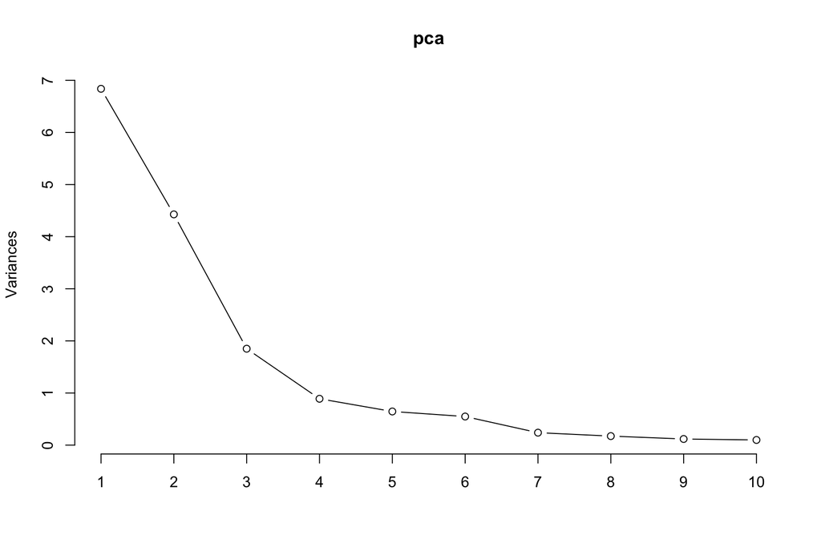

- Vyberme zvolený počet komoponentov (ako na to zistite z help)

Od teraz naše nové regresory reprezentujú poctane niečo iné ako tie pôvodné. Priložme odozvu k regresorom a znazornime si pairs graf.

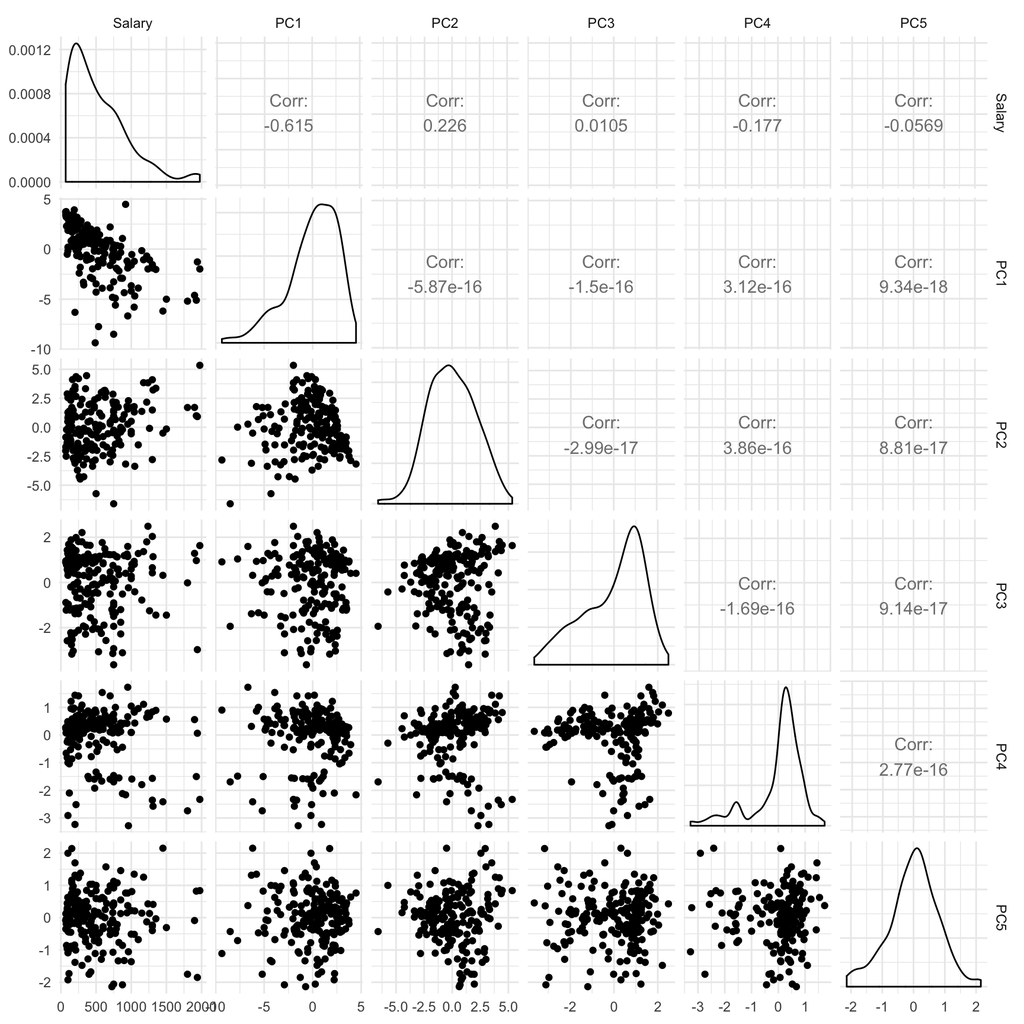

- Sme na tom teraz lepšie?

Určite by sa zišlo urobiť poriadnu diagnostiku a dáta odmodelovať. Pre krátkosť času tento krok preskočíme a len slepo fitneme plný regresný model.

```
##
## Call:
## lm(formula = Salary ~ ., data = pca_train)
##
## Residuals:
##     Min      1Q  Median      3Q     Max
## -866.02 -172.01  -33.83  123.48 1217.69
##
## Coefficients:
##             Estimate Std. Error t value Pr(>|t|)
## (Intercept)  520.452     21.583  24.114  < 2e-16 ***
## PC1          -95.927      8.275 -11.593  < 2e-16 ***
## PC2           43.747     10.283   4.254 3.28e-05 ***
## PC3            3.145     15.909   0.198 0.843505
## PC4          -76.713     22.943  -3.344 0.000995 ***
## PC5          -28.906     26.929  -1.073 0.284443
## ---
## Signif. codes:  0 '***' 0.001 '**' 0.01 '*' 0.05 '.' 0.1 ' ' 1
##
## Residual standard error: 302.9 on 191 degrees of freedom
## Multiple R-squared:  0.4633, Adjusted R-squared:  0.4492
## F-statistic: 32.97 on 5 and 191 DF,  p-value: < 2.2e-16
```

- Porovnajte tento model s klasickým lineárnym zo začiatku cvičení.

Teraz nemusite nič robiť. Ideme sa pozrieť na predikčnú silu modelu na nových testovacích dátach.

Najprv porovnajme *root mean square error* medzi fitom lineárneho modelu a odozvou. Potom na ukážku porovnajme predikčnú silu modelu na testovacích dátach.

```
##                          [,1]
## RMSE Modelu          281.7247
## RMSE testovacich dat 407.3190
```

Tak isto aj pre lineárny model, kde prediktory boli zložené z hlavných komponentov.

```
##                          [,1]
## RMSE Modelu          298.2790
## RMSE testovacich dat 436.9174
```

Plastickou redukciou parametrov sme dosiahli skoro rovnaký model z hladiska RMSE. Pripomenme, že pri druhom modeli sme nepoužili žiadny model seleciton, nastroj. *Poznámka: funkciou `pcr()` fitnete pca regresiu jedním ťahom.*

## Scvrkávacie regresné metódy

Prejdime k metódam nevyžadujúcim žiadne transformácie regresorov, prvá z nich je **Ridge regression** (hrebeňová regresia). V tomto prípade vieme odvodiť aj normálne rovnice:
$$\hat\beta = (X'X + \lambda I)^{-1} X'y$$

Lineárny model počas odhadovania parametrov kladie penáltu (cenu) na prediktory. Niektoré možno “pošle” k nule a urobí za vás model selection.

Na ukážku metódy vezmime rovnaké dáta a fitnime do trénovacich dát hrebeňovú regresiu. Na model použite funkciu `lm.ridge` z knižnice `MASS`. Hyper parameter $\lambda$ nech je tentokrát vektor `seq(0, 100, len=21)`, aby sme mohli sledovať vývoj odhadov prarametrov pri meniacom sa hyper parametri.

Zobrazme si odhady parametrov pri jednotlivých lambdách pomocou príkazu:

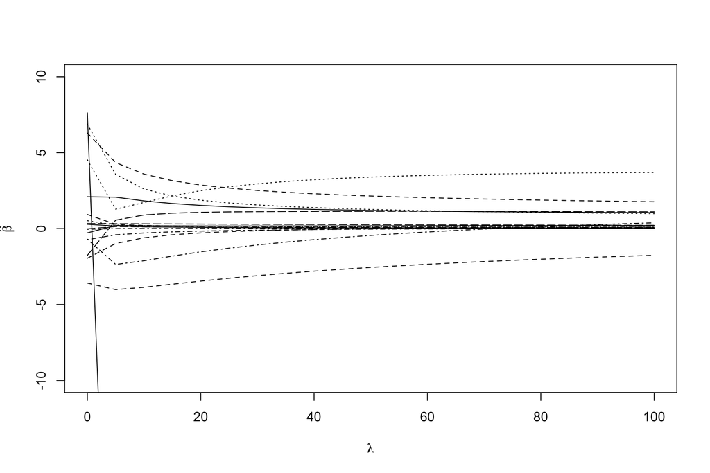

```r
matplot(rmo$lambda, coef(rmo), type="l", ylim=c(-10,10),
  xlab=expression(lambda),ylab=expression(hat(beta)),col=1)
```

Tá čiara idúca dole je intercept.

- Chápete prečo sa volá hrebeňová?
- Prečo je parameter $\lambda$ tak neumerne zvýšený?

Na zistenie optimalného paramera $\lambda$ použijme zovšeobecnenú “krížovúvalidáciu” (detailnejšie bude v naväzujúcom kurze) a to za pomoci `$GCV`. Na základe toho fitnime do dát model a zmerajme rovnaké hodnoty RMSE.

```
##                          [,1]
## RMSE Modelu          288.6547
## RMSE testovacich dat 428.5591
```

- Ako hodnotite výsledok?

Hodnoty sú vlastne rovnaké aj bez toho, aby sme použili niekedy zdĺhavé modelovanie.

Pokračujme s ďalšou scvrkávacou metódou v skratke **LASSO** (Least absolute shrinkage and selection operator). Tu už nevieme spočítať normálne rovnice, ale parametre sa dajú počítať inak. Algoritmus na odhad prametrov má veľkú výhodu, robí v jednom kroku **odhadovnie prametrov a model selection!**

**Funkcií implementovaných v Rku** je viacej my použime `lars` z rovnomennej knižnice. Znova fitnite model, pozor sme v oblasti machine learning (ML), tu sa už model zadáva inak ako pri linearnej regresii a jej podobných. Zároveň sa ťažko počíta inferencia.

Na zistenie vhodného parametra modelu znova využime krížovú validáciu s funkciou `cv.lars()`. Funkcia priamo ponúkne obrázok a stačí použiť oko.

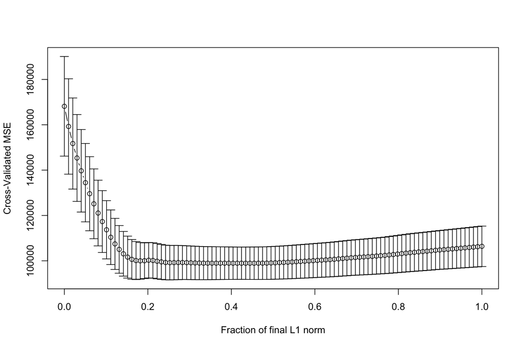

Znova urobme porovnanie predikčnej sily modelu na zaklade RMSE.

```
##                          [,1]
## RMSE Modelu          294.9951
## RMSE testovacich dat 435.2773
```

Dostávame v hrubom zmysle rovnaké výsledky. Dokonca sa javý lineárny model ako najlepší z hladiska predikčnej sily meranej pomocou RMSE. Predstavme si prípad , kde regresorov bude ďaleko viacej ako máme teraz. Následne by voľba najvhodnejšieho modelu a zároveň odhadu bola zložitejšia s klasickým lineárnym modelom. Všetko má svoje pre aj proti, **LASSO** navyše nevyžaduje také prísne predpoklady.

S penáltov kladenou na parametre sa dá ďalej “hrať”, preto vznikli rôzne kombinácie a verzie týchto metód.

## Samostatná práca

Vezmite dáta z predchádzajúcich cvičení `seatpos`, rozdelte dataset na trénovaciu a testovaciu vzorku a fitnite do dát podľa vás optimálny model s `hipcenter` ako odozvou. Potom využite nasledovné:

1. PCA regresiu
2. Ridge regresiu
3. LASSO

Na nájdenie najvhodnejšieho modelu na základe RMSE a porovnajte s lineárnym modelom.